# checkpoint2

Carlos Interaminense

June 27, 2017

# Analisando dados de filmes…

Neste post, vamos analisar os dados de filmes com base na quantidade de homens e mulheres em cada filme, assim como suas idades e quantidade de palavras que falaram nos filmes. A seguir, os dados são carregados, vamos desconsiderar dados inválidos, ou seja, valores ‘NULL’ e/ou ‘NA’.

```r
#Carrega os arquivos
personagens_informacoes = read_csv("character_list5.csv")
filmes = read_csv("meta_data7.csv")

# Filtra os filmes, descartando os que têm gross = 'NA'
filmes = filter(filmes, gross != 'NA')

#Filtra os personagens, descartando os que têm idade NULL
personagens_informacoes = filter (personagens_informacoes, age != 'NULL') %>%
  mutate(age = as.numeric(age))
```

Com as dados carregados, precisamos observar se existem valores inconsistentes nos nossos dados. Por exemplo, as idades dos personagens devem variar de 0 até 130, sende este último valor um valor empírico, pois consideramos que não há pessoas com mais de 130 anos de idade. Para observarmos isso, o histograma abaixo mostra se existe pessoas com idade fora do intervalo citado anteriormente [0-130]:

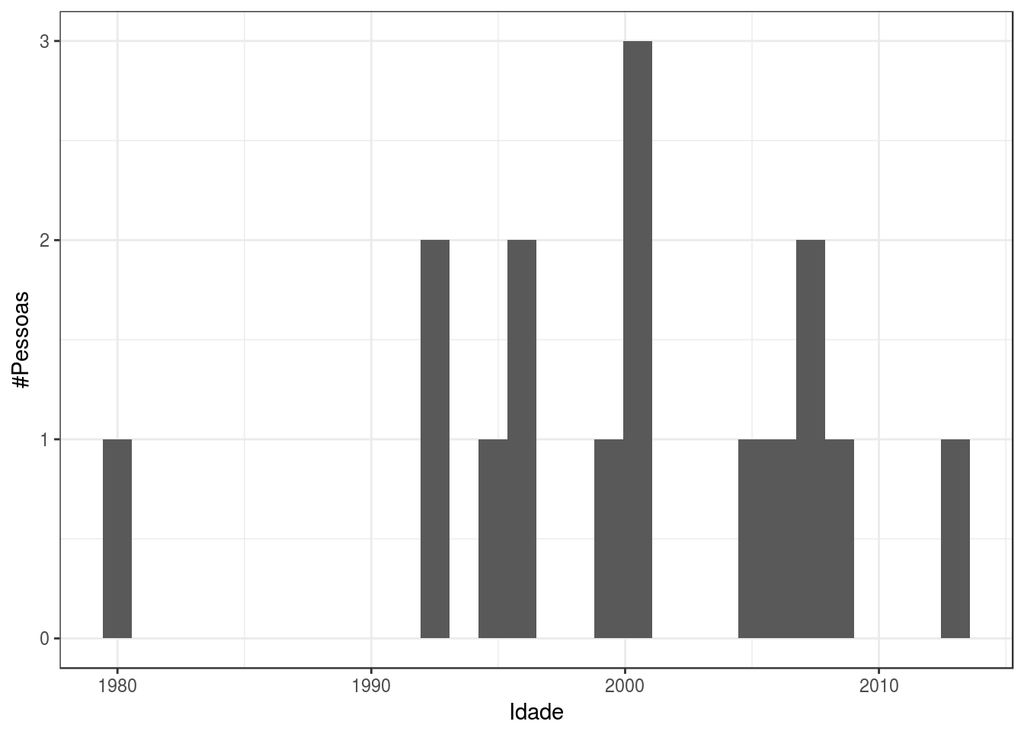

```r
personagens_informacoes %>%
  filter (age < 0 | age > 130) %>%
  ggplot(aes(x = age)) +
  geom_histogram() +
  ylab("#Pessoas") +
  xlab("Idade")
```

Percebemos que existem idades inconsistentes nos nossos dados, pessoas com idade superior a 1900 anos, logo, vamos remover os personagens que tem idade inferior a zero e superior a 130, a partir do código abaixo:

```r
personagens_informacoes = personagens_informacoes %>%
  filter(age >= 0 & age <= 130)
```

Agora, se observamos o histograma abaixo, percebemos que não existe pessoas com idades abaixo de zero e nem acima de 130.

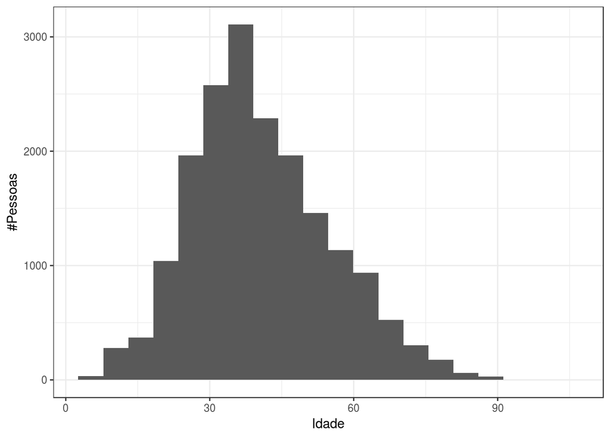

```r
personagens_informacoes %>%
  ggplot(aes(x = age)) +
  geom_histogram(bins = 20) +
  ylab("#Pessoas") +
  xlab("Idade")
```

O código abaixo separa as informações dos personagens homens dos mulheres, recuperando a quantidade de personagens do filme, mediana da idade e das quantidade de palavras, todas estas variáveis considerando por gênero, que serão os dados usados neste post. Em seguida, juntou-se as informações dos gêneros (número de personagens de cada gênero, idade e quantidade de palavras) e o título dos filmes, ou seja, no final vamos trabalhar com um conjunto com os seguintes dados:

- Quantidade de homens por filme;
- Quantidade de mulheres por filme;
- Mediana da quantidade das palavras ditas pelas mulheres em cada filma;
- Mediana da quantidade das palavras ditas pelos homens em cada filme;
- Mediana da idade das mulheres em cada filme;
- Mediana da idade dos homens em cada filme;

É importante falar que a mediana foi escolhida porque ela não sofre com valores extremos, o que acontece com a média.

```r
#junção das informações dos filmes com as dos personagens, a partir da variável em comum para ambos: 'script_id'
personagens_e_filmes= merge(filmes, personagens_informacoes, by="script_id")

# separação das informaões das mulheres
personagens_mulheres = personagens_e_filmes %>%
  filter(gender == "f") %>%
  group_by(script_id, imdb_id, title, year, gross) %>%
  summarize(qt_m=n(), p_m=median(words), i_m=median(age))

# separação das informaões dos homens
personagens_homens = personagens_e_filmes %>%
  filter(gender == "m") %>%
  group_by(script_id, imdb_id, title, year, gross) %>%
  summarize(qt_h=n(), p_h=median(words), i_h=median(age))

# junção das informações dos homens e mulheres
dados = merge(personagens_homens, personagens_mulheres, by=c('script_id','imdb_id','title','year','gross'))

# remoção de variáveis que não serão usadas neste relatório
dados = dados %>%
  subset(select = -c(script_id,imdb_id,year,gross))
```

# Agrupando com Kmeans

A próxima etapa é agrupar os dados usando o Kmeans. A quantidade de grupos que foi escolhida para que o kmeans retornasse foi 4 (quatro).

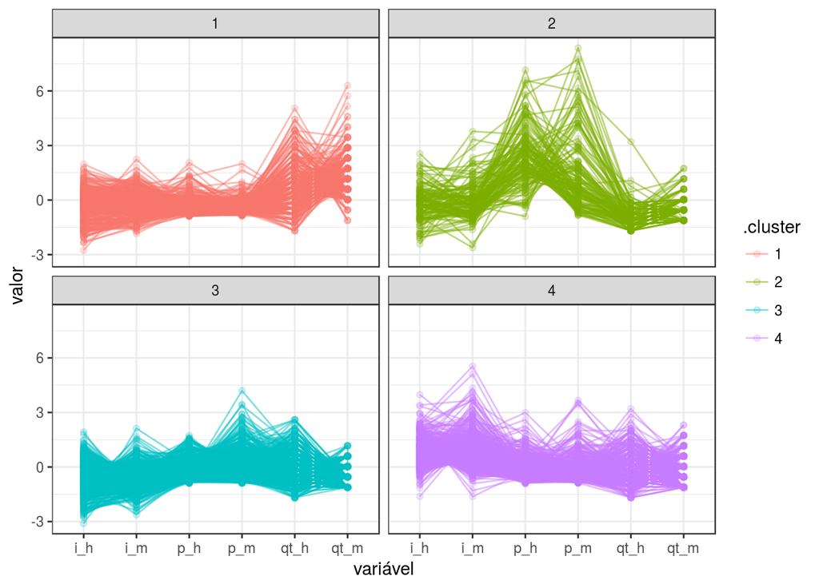

```r
dw = dados
dw2 <- dw

dw2.scaled = dw2 %>%
  mutate_each(funs(as.vector(scale(.))), 2:7)
# a linha a seguir é para que os grupos retornados pelo kmeans sejam determinísticos.
set.seed(123)

km = dw2.scaled %>%
    select(-title) %>%
    kmeans(centers = 4, nstart = 20)

dw2.scaled.km.long = km %>%
    augment(dw2.scaled) %>%
    gather(key = "variável",  value = "valor", -title, -.cluster)

dw2.scaled.km.long %>%
    ggplot(aes(x = `variável`, y = valor, group = title, colour = .cluster)) +
    geom_point(alpha = 0.2) +
    geom_line(alpha = .5) +
    facet_wrap(~ .cluster)
```

Em que, no gráfico acima:

- i_h: mediana das idades dos homens;
- i_m: mediana das idades das mulheres;
- gt_h: quantidade de homens;
- qt_m: quantidade de mulheres;
- p_h: mediana da quantidade das palavras ditas por homens; e
- p_m: mediana da quantidade das palavras ditas por mulheres.

# Batizando os Grupos…

- *grupo 1*: “Galera do smartphone”, apesar de ser o grupo com mais personagens (homens + mulheres) este foi o grup que menos falou, o que faz lembrar do nosso cotidiano nosso cotidiano, em que as pessoas ficam mais nos celulares do que interagindo com outras pessoas pessoalmente.  
  *grupo2*: “A experiência ‘fala’ mais ‘alto’”, este é o grupo que teve mais falas, somando as dos homens e das mulheres, e é o segundo grupo mais experiente (pessoas mais velhas). Engraçado que a quantidade de personagens (homens + mulheres) é a mais baixa de todos os grupos.  
  *grupo3*: “Mulheres sendo mulheres e homens sendo homens”, este grupo tem menos mulheres do que homens e mesmo assim elas falaram mais que eles.  
  *grupo4*: “Vovôs e vovós”, este é o grupo mais experiente (pessoas mais velhas). Percebe-se também que a quantidade de mulher e inferior a quantidade de homens, e mesmo assim, elas ainda falaram mais que eles.

Fazendo uma análise geral a partir da idade, percebe-se que as idades das mulheres e dos homens são parecidas nos grupos 1 e 3, já nos grupos 2 e 4, percebe-se que as mulheres têm, em geral, mais idade que os homens.  
É percebido também que as mulheres falam mais que os homens, no geral. Quanto a quantidade de homens e mulheres, percebe-se que, no grupo 3, elas são minoria enquanto no grupo 2 elas são maioria. Já nos grupo 1 e 4, eu diria que não há muita diferença na quantidade de mulheres e de homens, mesmo tendo picos que aparentam resultar em mais mulheres no grupo 1 e mais homens no grupo 4.